# Statistical testing

Audrey Baguette

Workshop Lead

Alex Diaz-Papkovich

Original Material

Adrien Osakwe

Original Material

September 24, 2025

# Loading libraries

```r
library(tidyverse)
```

# Two-samples t-test

1- First, we create two random samples from Normal distributions

```r
set.seed(20221011) # Seed for reproducibility
n <- 100 # Sample size

mu1 <- 0 # Mean of sample 1
mu2 <- 0.1 # Mean of sample 2

sd1 <- 1 # Standard deviation 1
sd2 <- 1 # Standard deviation 2
```

Generate two samples of of size n of normally-distributed data.

Sample x1 has a mean of mu1 and standard deviation sd1

Sample x2 has a mean of mu2 and standard deviation sd2

```r
x1 <- rnorm(n, mu1, sd1)
x2 <- rnorm(n, mu2, sd2)
```

2- We can take a look at the data with boxplots

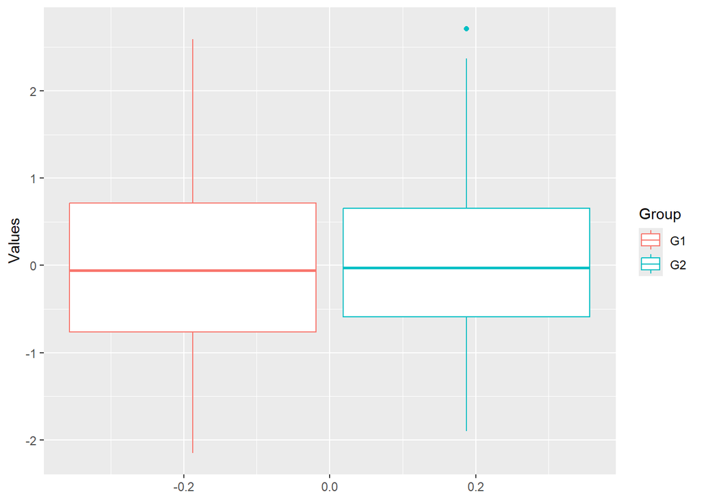

```r
x_df <- data.frame(Values = c(x1,x2),
                   Group = c(rep('G1',n),rep('G2',n)))
ggplot(x_df) + geom_boxplot(aes(y = Values, color = Group))
```

3- t-test

```r
t.test(x1, x2)
```

```
##
##  Welch Two Sample t-test
##
## data:  x1 and x2
## t = -0.79626, df = 196, p-value = 0.4268
## alternative hypothesis: true difference in means is not equal to 0
## 95 percent confidence interval:
##  -0.3866333  0.1642225
## sample estimates:
##   mean of x   mean of y
## -0.02866188  0.08254352
```

4- The result of the test is influenced by the sample size

```r
x3 <- rnorm(10000, mu1, sd1)
x4 <- rnorm(10000, mu2, sd2)
t.test(x3, x4)
```

```
##
##  Welch Two Sample t-test
##
## data:  x3 and x4
## t = -6.7389, df = 19994, p-value = 1.639e-11
## alternative hypothesis: true difference in means is not equal to 0
## 95 percent confidence interval:
##  -0.12390218 -0.06806612
## sample estimates:
##   mean of x   mean of y
## 0.006899738 0.102883890
```

4- We can also do a one-sided test Check if group2 is greater than group1 (aka the difference 1-2 is smaller)

```r
t.test(x1, x2, alternative = 'less')
```

```
##
##  Welch Two Sample t-test
##
## data:  x1 and x2
## t = -0.79626, df = 196, p-value = 0.2134
## alternative hypothesis: true difference in means is less than 0
## 95 percent confidence interval:
##       -Inf 0.1196047
## sample estimates:
##   mean of x   mean of y
## -0.02866188  0.08254352
```

# ANOVA

1- Create mutliple datasets

Our artificial data will have three different means

```r
set.seed(20221011)
m1 <- rnorm(30, mean = 25, sd = 5)
m2 <- rnorm(30, mean = 30, sd = 6)
m3 <- rnorm(30, mean = 22, sd = 7)

ms <- c(m1, m2, m3) # Combine our three measures into one vector

# Our vector of group labels A, B, and C
ls <- as.factor(c(rep("A",30),rep("B",30),rep("C",30)))
```

2- Visualize the data

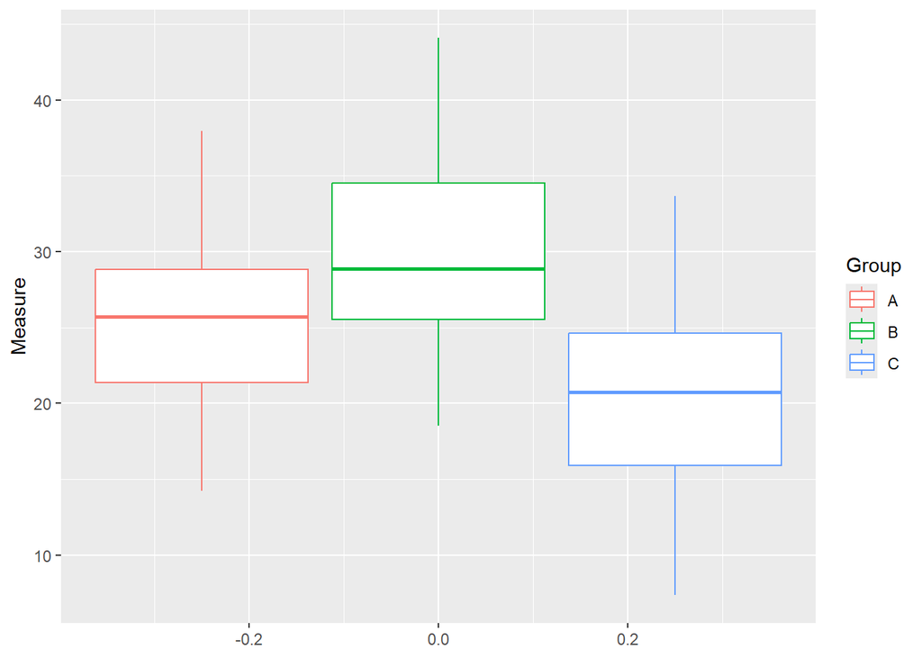

```r
df_anova <- data.frame(Measure = ms, Group = ls)
ggplot(df_anova) + geom_boxplot(aes(y = Measure, color = Group))
```

3- ANOVA

```r
results_aov <- aov(Measure ~ Group, data = df_anova)
summary(results_aov)
```

```
##             Df Sum Sq Mean Sq F value   Pr(>F)
## Group        2   1332   666.1   16.63 7.67e-07 ***
## Residuals   87   3486    40.1
## ---
## Signif. codes:  0 '***' 0.001 '**' 0.01 '*' 0.05 '.' 0.1 ' ' 1
```

We can look at the coefficients to find the difference across groups

```r
results_aov$coefficients
```

```
## (Intercept)      GroupB      GroupC
##   25.382285    4.521143   -4.900450
```

# Hands-on

## 1- ANOVA vs multiple t-tests

Data PlantGrowth has multiple groups: one control and two treatments

Make an ANOVA and consecutive t-tests between the control and each treatment. Do they lead to the same conclusion?

```r
head(PlantGrowth)
```

```
##   weight group
## 1   4.17  ctrl
## 2   5.58  ctrl
## 3   5.18  ctrl
## 4   6.11  ctrl
## 5   4.50  ctrl
## 6   4.61  ctrl
```

## 2- Multiple testing correction

Take the co2 dataset (note: not CO2), that records the CO2 level for each month across several years. We want to test if the CO2 levels from 1959 to 1978 were lower than those between 1979 and 1997 for each month separately. Then, we correct for multiple testing and compare the results (hint: see p.adjust). Do the conclusions change?

```r
co2_df <- data.frame(matrix(co2, 39, 12), row.names = as.character(c(1959:1997)))
colnames(co2_df) <- c('Jan', 'Feb', 'Mar', 'Apr', 'May', 'Jun', 'Jul', 'Aug', 'Sep', 'Oct', 'Nov', 'Dec')
```